# Explanatory_Analysis slides

>

## FACTORS THAT AFFECT PROSPER RATING AND HOW IT CAN BE USED TO PREDICT DELINQUENCY

## by Nurudeen Abdulsalaam

## Investigation Overview

In this investigation, I wanted to look at the features of prosper loan that could be used to predict their delinquency. The main focus was on the prosper rating, monthly income, occupation, and employment status

## Dataset Overview

|  | LoanKey | Term | LoanStatus | LoanOriginalAmount | ListingCategory (numeric) | ProsperRating (Alpha) | ListingCreationDate | BorrowerRate | IsBorrowerHomeowner | Occupation | StatedMonthlyIncome | EmploymentStatus | DelinquenciesLast7Years |
| --- | --- | --- | --- | --- | --- | --- | --- | --- | --- | --- | --- | --- | --- |
| 0 | E33A3400205839220442E84 | 36 | Completed | 9425 | 0 | NaN | 2007-08-26 19:09:29.263000000 | 0.1580 | True | Other | 3083.333333 | Self-employed | 4.0 |
| 1 | 9E3B37071505919926B1D82 | 36 | Current | 10000 | 2 | A | 2014-02-27 08:28:07.900000000 | 0.0920 | False | Professional | 6125.000000 | Employed | 0.0 |
| 2 | 6954337960046817851BCB2 | 36 | Completed | 3001 | 0 | NaN | 2007-01-05 15:00:47.090000000 | 0.2750 | False | Other | 2083.333333 | Not available | 0.0 |
| 3 | A0393664465886295619C51 | 36 | Current | 10000 | 16 | A | 2012-10-22 11:02:35.010000000 | 0.0974 | True | Skilled Labor | 2875.000000 | Employed | 14.0 |
| 4 | A180369302188889200689E | 36 | Current | 15000 | 2 | D | 2013-09-14 18:38:39.097000000 | 0.2085 | True | Executive | 9583.333333 | Employed | 0.0 |

## Filter out unique values

## Clean the data

|  | LoanKey | Term | LoanStatus | LoanAmount | ListingCategory | ProsperRating | ListingDate | BorrowerRate | Homeowner | Occupation | MonthlyIncome | EmploymentStatus | DelinquenciesLast7Years |
| --- | --- | --- | --- | --- | --- | --- | --- | --- | --- | --- | --- | --- | --- |
| 1 | 9E3B37071505919926B1D82 | 36 | Current | 10000 | Home Improvement | A | 2014-02-27 | 0.0920 | False | Professional | 6125.000000 | Employed | 0 |
| 3 | A0393664465886295619C51 | 36 | Current | 10000 | Motorcycle | A | 2012-10-22 | 0.0974 | True | Skilled Labor | 2875.000000 | Employed | 14 |
| 4 | A180369302188889200689E | 36 | Current | 15000 | Home Improvement | D | 2013-09-14 | 0.2085 | True | Executive | 9583.333333 | Employed | 0 |
| 5 | C3D63702273952547E79520 | 60 | Current | 15000 | Debt Consolidation | B | 2013-12-14 | 0.1314 | True | Professional | 8333.333333 | Employed | 0 |
| 6 | CE963680102927767790520 | 36 | Current | 3000 | Debt Consolidation | E | 2013-04-12 | 0.2712 | False | Sales - Retail | 2083.333333 | Employed | 0 |

## Distribution of Delinquency

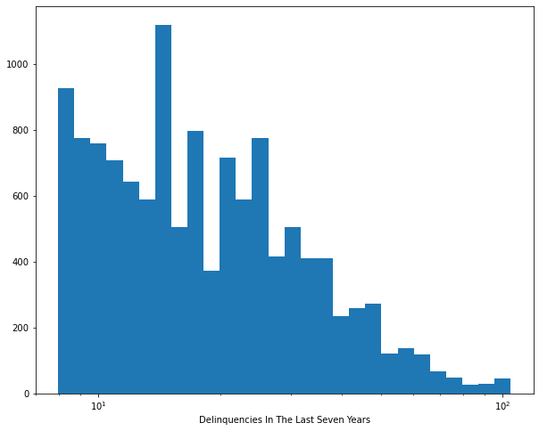

## Distribution of Prosper Rating

Looking at the plot below, we can see that a larger number of Borrowers has an Alpha Prosper Rating of A, B, C and D (17.13%, 18.30%, 21.55%, 16.87%) these translate to 2.00–3.99%, 4.00–5.99%, 6.00–8.99%, 9.00–11.99% Estimated Average Annual Loss Rat respectively. The largest value, 21.55%, is observed at C Rating. This implies that investor, on average stands a risk of not bein paid back by 4% - 8% which a good risk to take

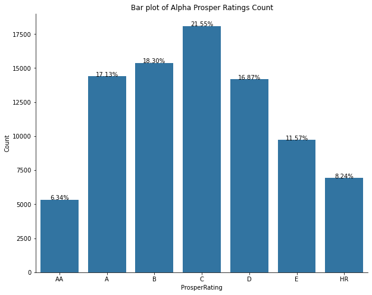

## Correlation Between Numerical Variables

While most of the varibles are negatively correlated with delinquencies, Borrower's rate, however, is possively correlated with delinquencies wich is also much more expected. This implies that as these variables increase, the probability that the borrower won't pay back decreases and vice versa

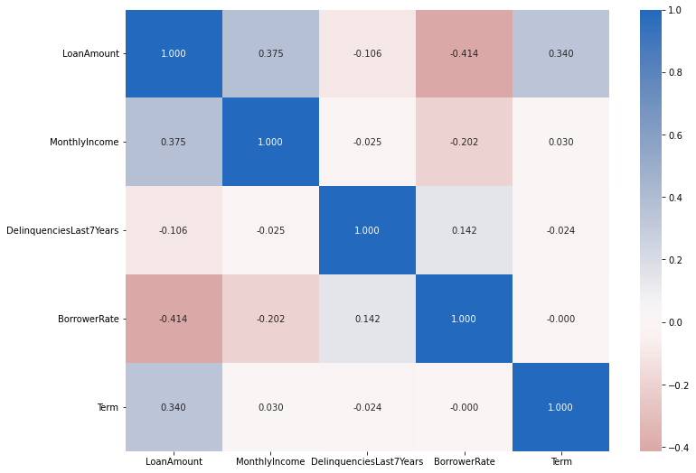

## Prosper Rating and House Ownnership

The relationship between house ownership of the borrower and the prosper rating. Observing the first four high ratings, AA A, B, and C, majority of the borrowers are house owners while the reverse is for low ratings, D and E.

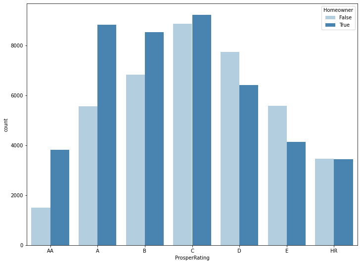

## Delinquencies, Monthly Income and Prosper Rating

Here, it can be seen that the prosper rating AA is commonly associated with high monthly income and low delinqueny. The reverse is seen for rating E. While rating B is somehow evenly distributed.

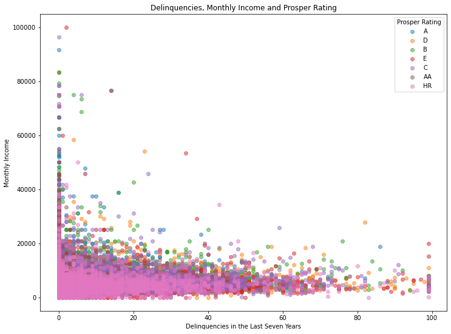

## Delinquencies, Borrower Rate and Prosper Rating

With this plot, I can save conclude that borrowers with good prosper rating, AA, borrow less frequently and rearly default. The opposite is true for those with bad or poor rating, E and HR. The same logic hold for other ratings as well

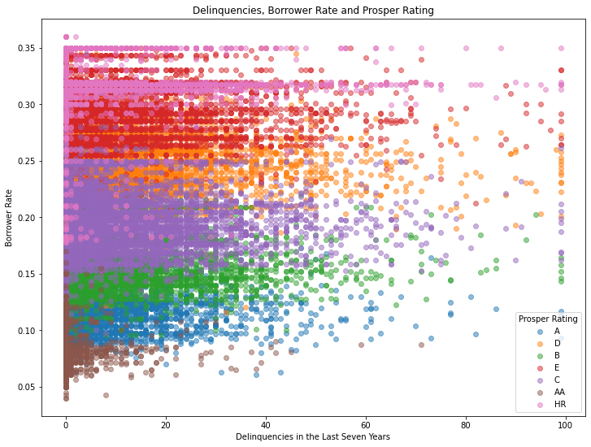

## Conclusions

> From the insights above, it is save to conclude that the monthly income, loan amount and borrower rate is a good predictor of the prosper rating with the later being a good predictor of delinquency.